# Reinforcement Learning

(Akshay Ratnawat)

1. Markov Chain and Transition Probabilities Estimation
2. Simulation under a Fixed Pre-Defined Policy

```python
import numpy as np

#pip install hmmviz
from hmmviz import TransGraph
import pandas as pd
import matplotlib.pyplot as plt
import seaborn as sns
```

```
array([[9.081e-01, 8.330e-02, 6.800e-03, 6.000e-04, 8.000e-04, 2.000e-04,
        1.000e-04, 1.000e-04],
       [7.000e-03, 9.065e-01, 7.790e-02, 6.400e-03, 6.000e-04, 1.300e-03,
        2.000e-04, 1.000e-04],
       [9.000e-04, 2.270e-02, 9.105e-01, 5.520e-02, 7.400e-03, 2.600e-03,
        1.000e-04, 6.000e-04],
       [2.000e-04, 3.300e-03, 5.950e-02, 8.593e-01, 5.300e-02, 1.170e-02,
        1.120e-02, 1.800e-03],
       [3.000e-04, 1.400e-03, 6.700e-03, 7.730e-02, 8.053e-01, 8.840e-02,
        1.000e-02, 1.060e-02],
       [1.000e-04, 1.100e-03, 2.400e-03, 4.300e-03, 6.480e-02, 8.346e-01,
        4.070e-02, 5.200e-02],
       [2.100e-03, 0.000e+00, 2.200e-03, 1.300e-02, 2.380e-02, 1.124e-01,
        6.486e-01, 1.979e-01],
       [0.000e+00, 0.000e+00, 0.000e+00, 0.000e+00, 0.000e+00, 0.000e+00,
        0.000e+00, 1.000e+00]])
```

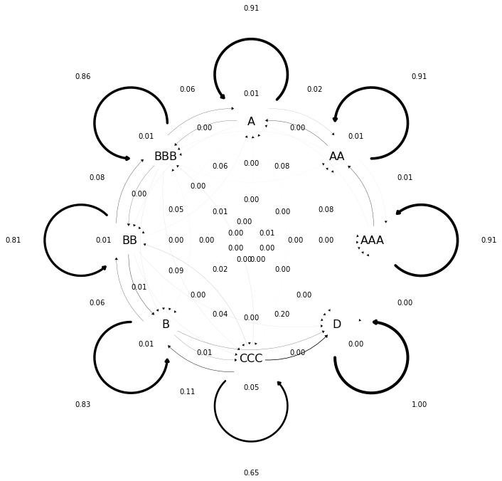

```python
# Transition Matrix
P = np.array([[90.81 , 8.33 ,  0.68 ,  0.06 ,  0.08 ,  0.02 ,  0.01 ,   0.01],
              [0.70 , 90.65 ,  7.79 ,  0.64 ,  0.06 ,  0.13 ,  0.02 ,   0.01],
              [0.09 ,  2.27 , 91.05 ,  5.52 ,  0.74 ,  0.26 ,  0.01 ,   0.06],
              [0.02 ,  0.33 ,  5.95 , 85.93 ,  5.30 ,  1.17 ,  1.12 ,   0.18],
              [0.03 ,  0.14 ,  0.67 ,  7.73 , 80.53 ,  8.84 ,  1.00 ,   1.06],
              [0.01 ,  0.11 ,  0.24 ,  0.43 ,  6.48 , 83.46 ,  4.07 ,   5.20],
              [0.21 ,  0.00 ,  0.22 ,  1.30 ,  2.38 , 11.24 , 64.86 ,  19.79],
              [0.00 ,  0.00 ,  0.00 ,  0.00 ,  0.00 ,  0.00 ,  0.00 , 100.00]])/100


labels = {'AAA': 'AAA',
          'AA': 'AA',
          'A': 'A',
          'BBB': 'BBB',
          'BB': 'BB',
          'B': 'B',
          'CCC': 'CCC',
          'D': 'D'}

graph = TransGraph.from_array(P, labels)
colors = {f's{i}': f'C{i}' for i in range(8)}
plt.figure(figsize=(12, 12))

graph.draw(
    nodelabels= labels, nodecolors= colors, edgelabels=True,
    nodefontsize=16,
)

P
```

#### Q1 Plot the n-step ahead probabilities, Pi,j(n)Pi,j(n) for n=1,2,…,100n=1,2,…,100 an for every ii and jj in {AAA,AA,A,BBB,BB,B,CCC,D}. Make sure to properly label each state based on the rating labels.

```python
T = 100
n = 8
P_mat = np.zeros((T,n,n), dtype=np.float64)
P_mat[0] = P

for t in range(1,T-1):
    P_mat[t] = np.matmul(P_mat[t-1],P)
```

```python
# Creating a DataFrame for each Step
n_step_probs = pd.DataFrame()
n_step_probs['Step'] = range(1, 101)

states = ['AAA', 'AA', 'A', 'BBB', 'BB', 'B', 'CCC', 'D']

for i in range(len(states)):
    for j in range(len(states)):
        cur_state = str(states[i] + '_' + states[j])
        n_step_probs[cur_state] = [item[i][j] for item in P_mat]
```

```python
n_step_probs = n_step_probs.set_index('Step')
n_step_probs.head()
```

| Step | AAA_AAA | AAA_AA | AAA_A | AAA_BBB | AAA_BB | AAA_B | AAA_CCC | AAA_D | AA_AAA | AA_AA | ... | CCC_CCC | CCC_D | D_AAA | D_AA | D_A | D_BBB | D_BB | D_B | D_CCC | D_D |
| --- | --- | --- | --- | --- | --- | --- | --- | --- | --- | --- | --- | --- | --- | --- | --- | --- | --- | --- | --- | --- | --- |
| 1 | 0.908100 | 0.083300 | 0.006800 | 0.000600 | 0.000800 | 0.000200 | 0.000100 | 0.000100 | 0.007000 | 0.906500 | ... | 0.648600 | 0.197900 | 0.0 | 0.0 | 0.0 | 0.0 | 0.0 | 0.0 | 0.0 | 1.0 |
| 2 | 0.825235 | 0.151314 | 0.018897 | 0.002033 | 0.001518 | 0.000563 | 0.000196 | 0.000243 | 0.012774 | 0.824117 | ... | 0.425641 | 0.332380 | 0.0 | 0.0 | 0.0 | 0.0 | 0.0 | 0.0 | 0.0 | 1.0 |
| 3 | 0.750474 | 0.206347 | 0.034738 | 0.004376 | 0.002262 | 0.001061 | 0.000303 | 0.000440 | 0.017502 | 0.751407 | ... | 0.283622 | 0.425895 | 0.0 | 0.0 | 0.0 | 0.0 | 0.0 | 0.0 | 0.0 | 1.0 |
| 4 | 0.682983 | 0.250375 | 0.053085 | 0.007632 | 0.003111 | 0.001680 | 0.000431 | 0.000703 | 0.021337 | 0.687122 | ... | 0.192697 | 0.492711 | 0.0 | 0.0 | 0.0 | 0.0 | 0.0 | 0.0 | 0.0 | 1.0 |
| 5 | 0.622021 | 0.285094 | 0.072962 | 0.011754 | 0.004118 | 0.002415 | 0.000588 | 0.001048 | 0.024413 | 0.630186 | ... | 0.134098 | 0.541926 | 0.0 | 0.0 | 0.0 | 0.0 | 0.0 | 0.0 | 0.0 | 1.0 |

5 rows × 64 columns

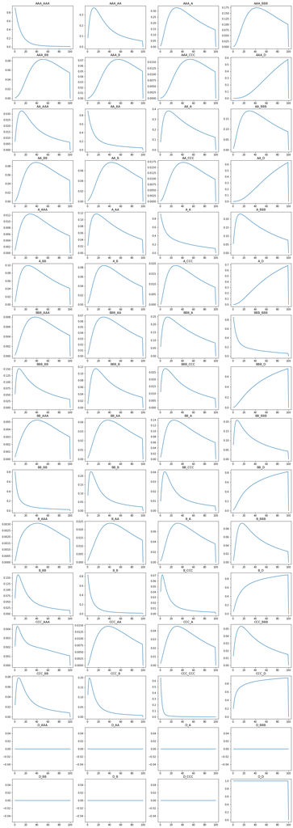

```python
# Plotting the Graphs
plt.figure(figsize=(20,60))

for i in range(len(n_step_probs.columns)):
    column = n_step_probs.columns[i]
    plt.subplot(16,4,i+1)
    plt.plot(n_step_probs[n_step_probs.columns[i]])
    plt.title(n_step_probs.columns[i])
```

#### 2) Group all states into classes. Report the classes and the total number of classes. Explain your answer.

From the above graphs we can see that AAA, AA, A, BBB, BB, B, CCC communicate with each other, thus they belong to same class, but state D does not communicate with each other thus it is a different class

Thus there are two classes: [AAA, AA, A, BBB, BB, B, CCC] and [D]

#### 3) What is the periodicity of the transition probability matrix? Explain your answer.

All the communicating class has the same periodicity. Thus we need to check the periodicity of only AAA and D.

Periodicity for AAA: From the N step graphs above we see that the probability of AAA to return to AAA or any other rating other than D is nowhere equal to 1. Thus from above it seems that the first class of bonds [AAA, AA, A, BBB, BB, B, CCC] is aperiodic

Periodicity of D: D is an absorbing state

#### 4) Construct a 100-step simulation for a bond rating assuming an initial AAA rating and the above transition matrix.

1. Plot the sequence of transitions as a step function of time.
2. Report the likehood of each transition and the likelihood of the entire simulated sequence.
3. Is this Markov chain stationary? Please provide detailed reasoning.
4. Is this Markov chain time homogeneous? Please provide detailed reasoning

```
Likelihood of getting this sequence is  7.210597764892215e-17
```

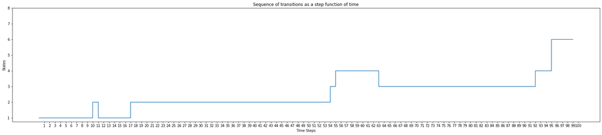

```python
# probability distribution for the initial value.
def markov__simulation(P, seed = 10):
    K = 100
    np.random.seed(seed)
    U = np.random.uniform(low=0.0, high=1.0, size=K)

    # simulation of the Markov chain
    Y = np.zeros(K,dtype=int)
    S = np.array([1,2,3,4,5,6,7,8],dtype=float)
    k = 0
    i = 0

    for u in U:

        # Starting with AAA
            if k == 0:
                j = 0
                Y[k] = S[j]

        # Simulations of the Transition Probabilities
            else:
                if u <= P[i,0]:
                    j = 0
                    Y[k] = S[j]
                elif u <= P[i,0] + P[i,1]:
                    j = 1
                    Y[k] = S[j]
                elif u <= P[i,0] + P[i,1] + P[i,2]:
                    j = 2
                    Y[k] = S[j]
                elif u <= P[i,0] + P[i,1] + P[i,2] + P[i,3]:
                    j = 3
                    Y[k] = S[j]
                elif u <= P[i,0] + P[i,1] + P[i,2] + P[i,3] + P[i,4]:
                    j = 4
                    Y[k] = S[j]
                elif u <= P[i,0] + P[i,1] + P[i,2] + P[i,3] + P[i,4] + P[i,5]:
                    j = 5
                    Y[k] = S[j]
                elif u <= P[i,0] + P[i,1] + P[i,2] + P[i,3] + P[i,4] + P[i,5] + P[i,6]:
                    j = 6
                    Y[k] = S[j]
                elif u <= P[i,0] + P[i,1] + P[i,2] + P[i,3] + P[i,4] + P[i,5] + P[i,6] + P[i,7]:
                    j = 7
                    Y[k] = S[j]
                else:
                    j = 8
                    Y[k] = S[j]
            k = k + 1
            i = j
    return Y


# Likelihood of the simulated Sequence:
p_sim = markov__simulation(P)

probability = []
for i in range(len(p_sim)-1):
    probability.append(P[p_sim[i], p_sim[i+1]])

print("Likelihood of getting this sequence is ",  np.prod(probability))

# Plotting the steps
plt.figure(figsize=(30,6))
plt.step(range(100), markov__simulation(P))
plt.title("Sequence of transitions as a step function of time")
plt.xlabel('Time Steps')
plt.ylabel('States')
plt.yticks(S)
plt.xticks(range(1, 101))
plt.show()
```

```python
# Getting a Sequence of transition steps from 1000 iterations

# Creating an empty list for sequences
P_sequence = []

for i in range(2000):
    P_sequence.extend(markov__simulation(P, None))
```

```python
# Creating a Data Frame for all the Sequece of steps taken

sim_transition_matrix = pd.DataFrame(P_sequence, columns = ['Initial'])

# # create a new column with data shifted one space
sim_transition_matrix['shift'] = sim_transition_matrix.shift(-1)

# # groupby and then unstack, fill the zeros
sim_trans_mat = sim_transition_matrix.groupby(['Initial', 'shift']).size().unstack().fillna(0)

# # normalise by occurences and save values to get transition matrix
sim_trans_mat = round(sim_trans_mat/(sim_trans_mat.sum(axis=1)),2)
sim_trans_mat.index = labels
sim_trans_mat.columns = labels
sim_trans_mat
```

|  | AAA | AA | A | BBB | BB | B | CCC | D |
| --- | --- | --- | --- | --- | --- | --- | --- | --- |
| AAA | 0.91 | 0.06 | 0.00 | 0.00 | 0.00 | 0.00 | 0.00 | 0.00 |
| AA | 0.01 | 0.90 | 0.06 | 0.01 | 0.00 | 0.00 | 0.00 | 0.00 |
| A | 0.01 | 0.03 | 0.90 | 0.10 | 0.03 | 0.01 | 0.00 | 0.00 |
| BBB | 0.01 | 0.00 | 0.03 | 0.86 | 0.11 | 0.03 | 0.13 | 0.00 |
| BB | 0.00 | 0.00 | 0.00 | 0.04 | 0.80 | 0.10 | 0.05 | 0.00 |
| B | 0.00 | 0.00 | 0.00 | 0.00 | 0.05 | 0.83 | 0.17 | 0.01 |
| CCC | 0.00 | 0.00 | 0.00 | 0.00 | 0.00 | 0.02 | 0.65 | 0.01 |
| D | 0.05 | 0.00 | 0.00 | 0.00 | 0.00 | 0.00 | 0.00 | 0.98 |

```python
# Original Transition Matrix
original_P = pd.DataFrame(P, index = labels, columns = labels)
original_P
```

|  | AAA | AA | A | BBB | BB | B | CCC | D |
| --- | --- | --- | --- | --- | --- | --- | --- | --- |
| AAA | 0.9081 | 0.0833 | 0.0068 | 0.0006 | 0.0008 | 0.0002 | 0.0001 | 0.0001 |
| AA | 0.0070 | 0.9065 | 0.0779 | 0.0064 | 0.0006 | 0.0013 | 0.0002 | 0.0001 |
| A | 0.0009 | 0.0227 | 0.9105 | 0.0552 | 0.0074 | 0.0026 | 0.0001 | 0.0006 |
| BBB | 0.0002 | 0.0033 | 0.0595 | 0.8593 | 0.0530 | 0.0117 | 0.0112 | 0.0018 |
| BB | 0.0003 | 0.0014 | 0.0067 | 0.0773 | 0.8053 | 0.0884 | 0.0100 | 0.0106 |
| B | 0.0001 | 0.0011 | 0.0024 | 0.0043 | 0.0648 | 0.8346 | 0.0407 | 0.0520 |
| CCC | 0.0021 | 0.0000 | 0.0022 | 0.0130 | 0.0238 | 0.1124 | 0.6486 | 0.1979 |
| D | 0.0000 | 0.0000 | 0.0000 | 0.0000 | 0.0000 | 0.0000 | 0.0000 | 1.0000 |

##### 4.3 Is this Markov Chain Stationary

No this distribution is not stationary as the Initial state distirbution changes as we multiply it with the transition Matrix

```python
# IF the initial state distribution is as p
p = [1,0,0,0,0,0,0,0]
np.matmul(p,P)
```

```
array([9.081e-01, 8.330e-02, 6.800e-03, 6.000e-04, 8.000e-04, 2.000e-04,
       1.000e-04, 1.000e-04])
```

```python
# Finding the Stationary Distribution for the Matrix P
one = np.array([[1,1,1,1,1,1,1,1]],dtype=float)
ONE = np.array([[1,1,1,1,1,1,1,1],
               [1,1,1,1,1,1,1,1],
               [1,1,1,1,1,1,1,1],
               [1,1,1,1,1,1,1,1],
               [1,1,1,1,1,1,1,1],
               [1,1,1,1,1,1,1,1],
               [1,1,1,1,1,1,1,1],
               [1,1,1,1,1,1,1,1]],dtype=float)
I = np.identity(8)
p = np.matmul(one,np.linalg.inv(I - P + ONE))
print(p)
```

```
[[-2.22044605e-15 -3.55271368e-15 -7.10542736e-15 -3.55271368e-15
   1.77635684e-15  0.00000000e+00  0.00000000e+00  1.00000000e+00]]
```

```python
# Checking if the Markoc process is Stationary or not
p = np.matmul(p,P)
print(p)
```

```
[[-1.89128124e-15 -3.57949861e-15 -6.82046595e-15 -3.17964572e-15
   7.28371656e-16  1.16739911e-16 -3.86862409e-17  1.00000000e+00]]
```

Thus if we use the above initial state probabilities then we will have a Stationary Markov Decision Chain.

#### 5) Compute the expected number of transitions between any pair of transient states before transitioning to the absorbing state.

```python
n = 8
H = P[0:(n-1),0:(n-1)]
H
```

```
array([[9.081e-01, 8.330e-02, 6.800e-03, 6.000e-04, 8.000e-04, 2.000e-04,
        1.000e-04],
       [7.000e-03, 9.065e-01, 7.790e-02, 6.400e-03, 6.000e-04, 1.300e-03,
        2.000e-04],
       [9.000e-04, 2.270e-02, 9.105e-01, 5.520e-02, 7.400e-03, 2.600e-03,
        1.000e-04],
       [2.000e-04, 3.300e-03, 5.950e-02, 8.593e-01, 5.300e-02, 1.170e-02,
        1.120e-02],
       [3.000e-04, 1.400e-03, 6.700e-03, 7.730e-02, 8.053e-01, 8.840e-02,
        1.000e-02],
       [1.000e-04, 1.100e-03, 2.400e-03, 4.300e-03, 6.480e-02, 8.346e-01,
        4.070e-02],
       [2.100e-03, 0.000e+00, 2.200e-03, 1.300e-02, 2.380e-02, 1.124e-01,
        6.486e-01]])
```

```python
Z = np.linalg.inv(np.identity(H.shape[0])-H)
Z
```

```
array([[12.88860222, 20.4234732 , 32.92181389, 19.77363127,  9.88073566,
         8.6936282 ,  1.94299496],
       [ 2.09688209, 21.56638558, 33.16314771, 19.8735292 ,  9.87872988,
         8.70041063,  1.94455555],
       [ 1.27366545, 10.54124747, 34.79655389, 20.0455318 ,  9.94545184,
         8.68604147,  1.94422776],
       [ 0.89182833,  7.12597916, 21.86309998, 21.9157819 ,  9.93123418,
         8.61052141,  1.98895279],
       [ 0.61692486,  4.70927306, 14.02903465, 13.02615168, 12.48326253,
         9.09566906,  1.83075044],
       [ 0.37384206,  2.74463332,  7.97236404,  7.14721153,  6.17952296,
        11.15670688,  1.69978804],
       [ 0.27935275,  1.64853515,  4.72365757,  4.22281999,  3.3108014 ,
         4.60954316,  3.61081961]])
```

#### 6) Compute the probability that a state j will ever be reached from state i (for all i and j)

```python
Q = np.zeros((7,7))
for i in range(len(Z)):
    for j in range(len(Z)):
        if i==j:
            x = 1
        else:
            x = 0
        Q[i][j] = (Z[i][j] - x)/(Z[j][j])

Q
```

```
array([[0.92241207, 0.94700492, 0.94612283, 0.90225534, 0.79151869,
        0.77922888, 0.53810358],
       [0.16269275, 0.95363154, 0.95305839, 0.90681361, 0.79135802,
        0.7798368 , 0.53853578],
       [0.09882107, 0.48878137, 0.97126152, 0.91466195, 0.79670293,
        0.77854886, 0.538445  ],
       [0.06919512, 0.33042065, 0.62831222, 0.95437078, 0.79556399,
        0.77177984, 0.55083139],
       [0.04786592, 0.21836172, 0.4031731 , 0.59437312, 0.91989274,
        0.81526468, 0.50701797],
       [0.02900563, 0.12726441, 0.22911361, 0.32612168, 0.49502467,
        0.91036782, 0.47074853],
       [0.0216744 , 0.07644003, 0.13575073, 0.19268398, 0.26521924,
        0.41316342, 0.72305457]])
```

## Mobile Robot

#### 1) Under the “always try to go right” policy:

1. rerun the code and recreate table 2.1, 2.4, and 2.6
2. recreate figures 2.2 and 2.3
3. construct the transition probability matrix

#### Table 2.1 States, actions and rewards for each step in an episode

```python
import numpy as np
import pandas as pd

#pip install gym
import gym
from gym import spaces
import matplotlib.pyplot as plt
```

```python
class Segment: #(gym.Env):

    def __init__(self,numActions,startObservation,p,terminal,done):
        self.numActions = numActions
        self.observation = startObservation
        self.p = p
        self.terminal = terminal
        self.action_space = spaces.Discrete(self.numActions) # {0:left, 1:right}
        self.observation_space = spaces.Discrete(2*self.terminal+1)
        self.done = done

    def step(self,action):
        assert self.action_space.contains(action)
        assert self.observation_space.contains(self.observation)
        assert self.action_space.n == 2
        assert self.observation!=0
        assert self.observation!=(2*self.terminal)
        observation = self.observation
        done = self.done
        if action==0:
            observation_next = observation + np.random.choice([-1,1],p=[self.p,1-self.p])
        elif action==1:
            observation_next = observation + np.random.choice([-1,1],p=[1-self.p,self.p])
        if observation_next == (2*self.terminal):
            done = True
        elif observation_next == 0:
            done = True
        self.done = done
        self.observation = observation_next
        reward=self.rewards(observation,observation_next,action)
        return [self.observation,reward,done]

    def rewards(self,observation,observation_next,action):
        if observation_next==(2*self.terminal):
            reward = 1.0
        elif observation_next==0:
            reward = -1.0
        else:
            reward = -0.05
        return reward

    def reset(self):
        observation = self.startObservation
        self.observation = observation
        self.done = False
        return observation
```

```python
t=0
tMAX = 50
done = False
observation = 10
observations = [observation]
rewards = []
actions = []
```

```python
# this is a hard coded policy
def policy(observation):
    action = 1
    return action
```

```python
env = Segment(numActions=2,startObservation=10,p=0.8,terminal=10,done=False)
while t <tMAX and done==False:
    action = policy(observation=observation)
    observation_next,reward,done = env.step(action=action)
    observations.append(observation_next)
    rewards.append(reward)
    actions.append(action)
    observation = observation_next
    t+=1
```

```python
dta = pd.DataFrame(
             [range(0,t),
              observations[0:t],
              observations[1:(t+1)],
              actions[0:t],
              rewards]).transpose()

dta.columns = ['t','observation','observation_next','action','reward']
dta['observation'] = dta['observation'] - 10
dta['observation_next'] = dta['observation_next'] - 10
dta['beta'] = 0.98
dta['beta^t'] = dta['beta']**dta['t']
dta['beta^t_reward'] = dta['beta^t']*dta['reward']
```

```python
dta
```

|  | t | observation | observation_next | action | reward | beta | beta^t | beta^t_reward |
| --- | --- | --- | --- | --- | --- | --- | --- | --- |
| 0 | 0.0 | 0.0 | -1.0 | 1.0 | -0.05 | 0.98 | 1.000000 | -0.050000 |
| 1 | 1.0 | -1.0 | 0.0 | 1.0 | -0.05 | 0.98 | 0.980000 | -0.049000 |
| 2 | 2.0 | 0.0 | -1.0 | 1.0 | -0.05 | 0.98 | 0.960400 | -0.048020 |
| 3 | 3.0 | -1.0 | 0.0 | 1.0 | -0.05 | 0.98 | 0.941192 | -0.047060 |
| 4 | 4.0 | 0.0 | 1.0 | 1.0 | -0.05 | 0.98 | 0.922368 | -0.046118 |
| 5 | 5.0 | 1.0 | 2.0 | 1.0 | -0.05 | 0.98 | 0.903921 | -0.045196 |
| 6 | 6.0 | 2.0 | 3.0 | 1.0 | -0.05 | 0.98 | 0.885842 | -0.044292 |
| 7 | 7.0 | 3.0 | 2.0 | 1.0 | -0.05 | 0.98 | 0.868126 | -0.043406 |
| 8 | 8.0 | 2.0 | 3.0 | 1.0 | -0.05 | 0.98 | 0.850763 | -0.042538 |
| 9 | 9.0 | 3.0 | 4.0 | 1.0 | -0.05 | 0.98 | 0.833748 | -0.041687 |
| 10 | 10.0 | 4.0 | 5.0 | 1.0 | -0.05 | 0.98 | 0.817073 | -0.040854 |
| 11 | 11.0 | 5.0 | 6.0 | 1.0 | -0.05 | 0.98 | 0.800731 | -0.040037 |
| 12 | 12.0 | 6.0 | 7.0 | 1.0 | -0.05 | 0.98 | 0.784717 | -0.039236 |
| 13 | 13.0 | 7.0 | 8.0 | 1.0 | -0.05 | 0.98 | 0.769022 | -0.038451 |
| 14 | 14.0 | 8.0 | 7.0 | 1.0 | -0.05 | 0.98 | 0.753642 | -0.037682 |
| 15 | 15.0 | 7.0 | 8.0 | 1.0 | -0.05 | 0.98 | 0.738569 | -0.036928 |
| 16 | 16.0 | 8.0 | 9.0 | 1.0 | -0.05 | 0.98 | 0.723798 | -0.036190 |
| 17 | 17.0 | 9.0 | 10.0 | 1.0 | 1.00 | 0.98 | 0.709322 | 0.709322 |

#### Table 2.4 Summary statistics of the sum of discounted realized rewards across all episodes

```python
# Running for all the episodes

allEpisodes_same_state = pd.DataFrame()
for e in range(0,1000):
    t=0
    tMAX = 50
    done = False
    observation = 10
    observations = [observation]
    rewards = []
    actions = []
    env = Segment(numActions=2,startObservation=10,p=0.8,terminal=10,done=False)
    while t <tMAX and done==False:
        action = policy(observation=observation)
        observation_next,reward,done = env.step(action=action)
        observations.append(observation_next)
        rewards.append(reward)
        actions.append(action)
        observation = observation_next
        t+=1
    dta = pd.DataFrame(
                 [[e]*t,
                  range(0,t),
                  observations[0:t],
                  observations[1:(t+1)],
                  actions[0:t],
                  rewards]).transpose()
    dta.columns = ['episode','t','observation','observation_next','action','reward']
    dta['observation'] = dta['observation'] - 10
    dta['observation_next'] = dta['observation_next'] - 10
    dta['beta'] = 0.98
    dta['beta^t'] = dta['beta']**dta['t']
    dta['beta^t_reward'] = dta['beta^t']*dta['reward']
    allEpisodes_same_state = allEpisodes_same_state.append(dta,ignore_index=True)
```

```python
allEpisodes_same_state
```

|  | episode | t | observation | observation_next | action | reward | beta | beta^t | beta^t_reward |
| --- | --- | --- | --- | --- | --- | --- | --- | --- | --- |
| 0 | 0.0 | 0.0 | 0.0 | 1.0 | 1.0 | -0.05 | 0.98 | 1.000000 | -0.050000 |
| 1 | 0.0 | 1.0 | 1.0 | 2.0 | 1.0 | -0.05 | 0.98 | 0.980000 | -0.049000 |
| 2 | 0.0 | 2.0 | 2.0 | 3.0 | 1.0 | -0.05 | 0.98 | 0.960400 | -0.048020 |
| 3 | 0.0 | 3.0 | 3.0 | 4.0 | 1.0 | -0.05 | 0.98 | 0.941192 | -0.047060 |
| 4 | 0.0 | 4.0 | 4.0 | 5.0 | 1.0 | -0.05 | 0.98 | 0.922368 | -0.046118 |
| ... | ... | ... | ... | ... | ... | ... | ... | ... | ... |
| 16671 | 999.0 | 13.0 | 7.0 | 8.0 | 1.0 | -0.05 | 0.98 | 0.769022 | -0.038451 |
| 16672 | 999.0 | 14.0 | 8.0 | 7.0 | 1.0 | -0.05 | 0.98 | 0.753642 | -0.037682 |
| 16673 | 999.0 | 15.0 | 7.0 | 8.0 | 1.0 | -0.05 | 0.98 | 0.738569 | -0.036928 |
| 16674 | 999.0 | 16.0 | 8.0 | 9.0 | 1.0 | -0.05 | 0.98 | 0.723798 | -0.036190 |
| 16675 | 999.0 | 17.0 | 9.0 | 10.0 | 1.0 | 1.00 | 0.98 | 0.709322 | 0.709322 |

16676 rows × 9 columns

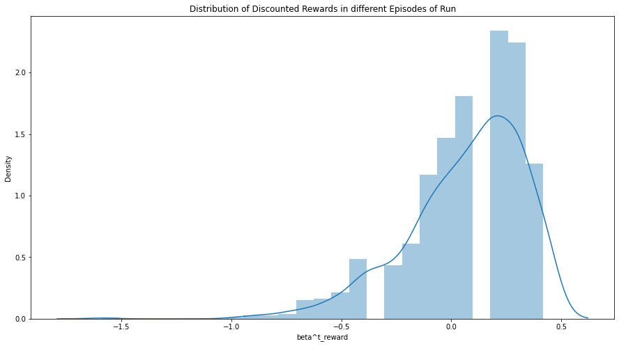

```python
# Plotting the Sum of discounted rewards in different episodes
sum_rewards = allEpisodes_same_state.groupby('episode')['beta^t_reward'].sum()

plt.figure(figsize=(15,8))
sns.distplot(sum_rewards)
plt.title('Distribution of Discounted Rewards in different Episodes of Run')
```

```python
sum_rewards.describe()
```

```
count    1000.000000
mean        0.064590
std         0.268121
min        -1.589576
25%        -0.115686
50%         0.084992
75%         0.302560
max         0.418117
Name: beta^t_reward, dtype: float64
```

#### Table 2.6: Summary statistics of the sum of discounted realized rewards across all episodes for each initial state

```python
allEpisodes = pd.DataFrame()
obs = range(1,20)
for o in obs:
    for e in range(0,1000):
        t=0
        tMAX = 50
        done = False
        observation = np.int(o)
        observations = [observation]
        rewards = []
        actions = []
        env = Segment(numActions=2,startObservation=observation,p=0.8,terminal=10,done=False)
        while t <tMAX and done==False:
            action = policy(observation=observation)
            observation_next,reward,done = env.step(action=action)
            observations.append(observation_next)
            rewards.append(reward)
            actions.append(action)
            observation = observation_next
            t+=1
        dta = pd.DataFrame(
                    [[o-10]*t,
                    [e]*t,
                    range(0,t),
                    observations[0:t],
                    observations[1:(t+1)],
                    actions[0:t],
                    rewards]).transpose()
        dta.columns = ['initial','episode','t','observation','observation_next','action','reward']
        dta['observation'] = dta['observation'] - 10
        dta['observation_next'] = dta['observation_next'] - 10
        dta['beta'] = 0.98
        dta['beta^t'] = dta['beta']**dta['t']
        dta['beta^t_reward'] = dta['beta^t']*dta['reward']
        allEpisodes = allEpisodes.append(dta,ignore_index=True)
```

```python
allEpisodes
```

|  | initial | episode | t | observation | observation_next | action | reward | beta | beta^t | beta^t_reward |
| --- | --- | --- | --- | --- | --- | --- | --- | --- | --- | --- |
| 0 | -9.0 | 0.0 | 0.0 | -9.0 | -8.0 | 1.0 | -0.05 | 0.98 | 1.000000 | -0.050000 |
| 1 | -9.0 | 0.0 | 1.0 | -8.0 | -7.0 | 1.0 | -0.05 | 0.98 | 0.980000 | -0.049000 |
| 2 | -9.0 | 0.0 | 2.0 | -7.0 | -6.0 | 1.0 | -0.05 | 0.98 | 0.960400 | -0.048020 |
| 3 | -9.0 | 0.0 | 3.0 | -6.0 | -5.0 | 1.0 | -0.05 | 0.98 | 0.941192 | -0.047060 |
| 4 | -9.0 | 0.0 | 4.0 | -5.0 | -4.0 | 1.0 | -0.05 | 0.98 | 0.922368 | -0.046118 |
| ... | ... | ... | ... | ... | ... | ... | ... | ... | ... | ... |
| 305734 | 9.0 | 999.0 | 4.0 | 9.0 | 8.0 | 1.0 | -0.05 | 0.98 | 0.922368 | -0.046118 |
| 305735 | 9.0 | 999.0 | 5.0 | 8.0 | 9.0 | 1.0 | -0.05 | 0.98 | 0.903921 | -0.045196 |
| 305736 | 9.0 | 999.0 | 6.0 | 9.0 | 8.0 | 1.0 | -0.05 | 0.98 | 0.885842 | -0.044292 |
| 305737 | 9.0 | 999.0 | 7.0 | 8.0 | 9.0 | 1.0 | -0.05 | 0.98 | 0.868126 | -0.043406 |
| 305738 | 9.0 | 999.0 | 8.0 | 9.0 | 10.0 | 1.0 | 1.00 | 0.98 | 0.850763 | 0.850763 |

305739 rows × 10 columns

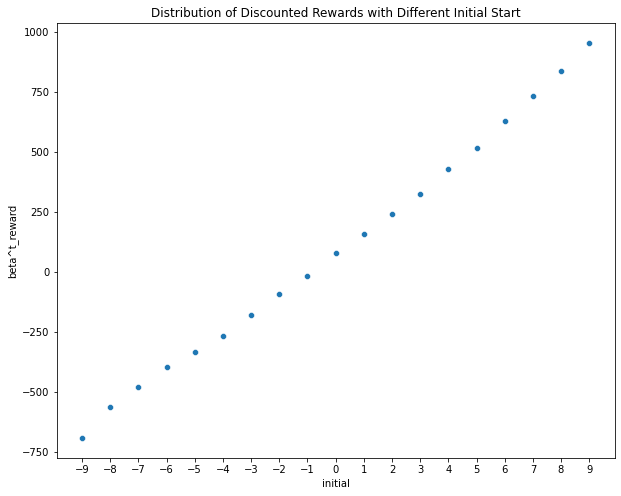

```python
# Plotting the Sum of discounted rewards in different episodes
sum_rewards_all_states = allEpisodes.groupby(['initial'])['beta^t_reward'].sum().reset_index()
sum_rewards_all_states

plt.figure(figsize=(10,8))
sns.scatterplot(sum_rewards_all_states['initial'], sum_rewards_all_states['beta^t_reward'])
plt.title('Distribution of Discounted Rewards with Different Initial Start')
plt.xticks(range(-9, 10))
plt.show()
```

```python
transitions = allEpisodes['observation']

transitions_matrix = pd.DataFrame(transitions)
# create a new column with data shifted one space
transitions_matrix['shift'] = transitions_matrix.shift(-1)

# groupby and then unstack, fill the zeros
trans_mat = transitions_matrix.groupby(['observation', 'shift']).size().unstack().fillna(0)

# normalise by occurences and save values to get transition matrix
trans_mat = round(trans_mat/(trans_mat.sum(axis=1)),2)
trans_mat
```

| shift observation | -9.0 | -8.0 | -7.0 | -6.0 | -5.0 | -4.0 | -3.0 | -2.0 | -1.0 | 0.0 | 1.0 | 2.0 | 3.0 | 4.0 | 5.0 | 6.0 | 7.0 | 8.0 | 9.0 |
| --- | --- | --- | --- | --- | --- | --- | --- | --- | --- | --- | --- | --- | --- | --- | --- | --- | --- | --- | --- |
| -9.0 | 0.14 | 0.43 | 0.01 | 0.00 | 0.00 | 0.00 | 0.00 | 0.00 | 0.00 | 0.00 | 0.00 | 0.00 | 0.00 | 0.00 | 0.00 | 0.00 | 0.00 | 0.0 | 0.00 |
| -8.0 | 0.42 | 0.00 | 0.53 | 0.00 | 0.00 | 0.00 | 0.00 | 0.00 | 0.00 | 0.00 | 0.00 | 0.00 | 0.00 | 0.00 | 0.00 | 0.00 | 0.00 | 0.0 | 0.00 |
| -7.0 | 0.00 | 0.30 | 0.00 | 0.60 | 0.00 | 0.00 | 0.00 | 0.00 | 0.00 | 0.00 | 0.00 | 0.00 | 0.00 | 0.00 | 0.00 | 0.00 | 0.00 | 0.0 | 0.00 |
| -6.0 | 0.00 | 0.00 | 0.27 | 0.00 | 0.63 | 0.00 | 0.00 | 0.00 | 0.00 | 0.00 | 0.00 | 0.00 | 0.00 | 0.00 | 0.00 | 0.00 | 0.00 | 0.0 | 0.00 |
| -5.0 | 0.00 | 0.00 | 0.00 | 0.25 | 0.00 | 0.67 | 0.00 | 0.00 | 0.00 | 0.00 | 0.00 | 0.00 | 0.00 | 0.00 | 0.00 | 0.00 | 0.00 | 0.0 | 0.00 |
| -4.0 | 0.00 | 0.00 | 0.00 | 0.00 | 0.25 | 0.00 | 0.68 | 0.00 | 0.00 | 0.00 | 0.00 | 0.00 | 0.00 | 0.00 | 0.00 | 0.00 | 0.00 | 0.0 | 0.00 |
| -3.0 | 0.00 | 0.00 | 0.00 | 0.00 | 0.00 | 0.23 | 0.00 | 0.70 | 0.00 | 0.00 | 0.00 | 0.00 | 0.00 | 0.00 | 0.00 | 0.00 | 0.00 | 0.0 | 0.00 |
| -2.0 | 0.00 | 0.00 | 0.00 | 0.00 | 0.00 | 0.00 | 0.23 | 0.00 | 0.71 | 0.00 | 0.00 | 0.00 | 0.00 | 0.00 | 0.00 | 0.00 | 0.00 | 0.0 | 0.00 |
| -1.0 | 0.00 | 0.00 | 0.00 | 0.00 | 0.00 | 0.00 | 0.00 | 0.23 | 0.00 | 0.72 | 0.00 | 0.00 | 0.00 | 0.00 | 0.00 | 0.00 | 0.00 | 0.0 | 0.00 |
| 0.0 | 0.00 | 0.00 | 0.00 | 0.00 | 0.00 | 0.00 | 0.00 | 0.00 | 0.22 | 0.00 | 0.73 | 0.00 | 0.00 | 0.00 | 0.00 | 0.00 | 0.00 | 0.0 | 0.00 |
| 1.0 | 0.00 | 0.00 | 0.00 | 0.00 | 0.00 | 0.00 | 0.00 | 0.00 | 0.00 | 0.22 | 0.00 | 0.73 | 0.00 | 0.00 | 0.00 | 0.00 | 0.00 | 0.0 | 0.00 |
| 2.0 | 0.00 | 0.00 | 0.00 | 0.00 | 0.00 | 0.00 | 0.00 | 0.00 | 0.00 | 0.00 | 0.22 | 0.00 | 0.74 | 0.00 | 0.00 | 0.00 | 0.00 | 0.0 | 0.00 |
| 3.0 | 0.00 | 0.00 | 0.00 | 0.00 | 0.00 | 0.00 | 0.00 | 0.00 | 0.00 | 0.00 | 0.00 | 0.22 | 0.00 | 0.74 | 0.00 | 0.00 | 0.00 | 0.0 | 0.00 |
| 4.0 | 0.00 | 0.00 | 0.00 | 0.00 | 0.00 | 0.00 | 0.00 | 0.00 | 0.00 | 0.00 | 0.00 | 0.00 | 0.22 | 0.00 | 0.75 | 0.00 | 0.00 | 0.0 | 0.00 |
| 5.0 | 0.00 | 0.00 | 0.00 | 0.00 | 0.00 | 0.00 | 0.00 | 0.00 | 0.00 | 0.00 | 0.00 | 0.00 | 0.00 | 0.21 | 0.00 | 0.75 | 0.00 | 0.0 | 0.00 |
| 6.0 | 0.00 | 0.00 | 0.00 | 0.00 | 0.00 | 0.00 | 0.00 | 0.00 | 0.00 | 0.00 | 0.00 | 0.00 | 0.00 | 0.00 | 0.21 | 0.00 | 0.76 | 0.0 | 0.00 |
| 7.0 | 0.00 | 0.00 | 0.00 | 0.00 | 0.00 | 0.00 | 0.00 | 0.00 | 0.00 | 0.00 | 0.00 | 0.00 | 0.00 | 0.00 | 0.00 | 0.21 | 0.00 | 0.8 | 0.00 |
| 8.0 | 0.01 | 0.00 | 0.00 | 0.00 | 0.00 | 0.00 | 0.00 | 0.00 | 0.00 | 0.00 | 0.00 | 0.00 | 0.00 | 0.00 | 0.00 | 0.00 | 0.20 | 0.0 | 0.96 |
| 9.0 | 0.43 | 0.27 | 0.19 | 0.15 | 0.12 | 0.10 | 0.09 | 0.07 | 0.07 | 0.06 | 0.05 | 0.05 | 0.05 | 0.04 | 0.04 | 0.04 | 0.04 | 0.2 | 0.04 |

### 2) Under the “always try to go left” policy:

1. rerun the code and recreate table 2.1, 2.4, and 2.6
2. recreate figures 2.2 and 2.3
3. construct the transition probability matrix

#### Table 2.1 States, actions and rewards for each step in an episode

```python
t=0
tMAX = 50
done = False
observation = 10
observations = [observation]
rewards = []
actions = []

# this is a hard coded policy for going left
def policy(observation):
    action = 0
    return action
```

```python
env = Segment(numActions=2,startObservation=10,p=0.8,terminal=10,done=False)
while t <tMAX and done==False:
    action = policy(observation=observation)
    observation_next,reward,done = env.step(action=action)
    observations.append(observation_next)
    rewards.append(reward)
    actions.append(action)
    observation = observation_next
    t+=1
```

```python
dta_left = pd.DataFrame(
             [range(0,t),
              observations[0:t],
              observations[1:(t+1)],
              actions[0:t],
              rewards]).transpose()

dta_left.columns = ['t','observation','observation_next','action','reward']
dta_left['observation'] = dta_left['observation'] - 10
dta_left['observation_next'] = dta_left['observation_next'] - 10
dta_left['beta'] = 0.98
dta_left['beta^t'] = dta_left['beta']**dta_left['t']
dta_left['beta^t_reward'] = dta_left['beta^t']*dta_left['reward']

dta_left
```

|  | t | observation | observation_next | action | reward | beta | beta^t | beta^t_reward |
| --- | --- | --- | --- | --- | --- | --- | --- | --- |
| 0 | 0.0 | 0.0 | -1.0 | 0.0 | -0.05 | 0.98 | 1.000000 | -0.050000 |
| 1 | 1.0 | -1.0 | -2.0 | 0.0 | -0.05 | 0.98 | 0.980000 | -0.049000 |
| 2 | 2.0 | -2.0 | -3.0 | 0.0 | -0.05 | 0.98 | 0.960400 | -0.048020 |
| 3 | 3.0 | -3.0 | -4.0 | 0.0 | -0.05 | 0.98 | 0.941192 | -0.047060 |
| 4 | 4.0 | -4.0 | -5.0 | 0.0 | -0.05 | 0.98 | 0.922368 | -0.046118 |
| 5 | 5.0 | -5.0 | -4.0 | 0.0 | -0.05 | 0.98 | 0.903921 | -0.045196 |
| 6 | 6.0 | -4.0 | -3.0 | 0.0 | -0.05 | 0.98 | 0.885842 | -0.044292 |
| 7 | 7.0 | -3.0 | -4.0 | 0.0 | -0.05 | 0.98 | 0.868126 | -0.043406 |
| 8 | 8.0 | -4.0 | -5.0 | 0.0 | -0.05 | 0.98 | 0.850763 | -0.042538 |
| 9 | 9.0 | -5.0 | -6.0 | 0.0 | -0.05 | 0.98 | 0.833748 | -0.041687 |
| 10 | 10.0 | -6.0 | -5.0 | 0.0 | -0.05 | 0.98 | 0.817073 | -0.040854 |
| 11 | 11.0 | -5.0 | -6.0 | 0.0 | -0.05 | 0.98 | 0.800731 | -0.040037 |
| 12 | 12.0 | -6.0 | -7.0 | 0.0 | -0.05 | 0.98 | 0.784717 | -0.039236 |
| 13 | 13.0 | -7.0 | -8.0 | 0.0 | -0.05 | 0.98 | 0.769022 | -0.038451 |
| 14 | 14.0 | -8.0 | -9.0 | 0.0 | -0.05 | 0.98 | 0.753642 | -0.037682 |
| 15 | 15.0 | -9.0 | -10.0 | 0.0 | -1.00 | 0.98 | 0.738569 | -0.738569 |

#### Table 2.4 Summary statistics of the sum of discounted realized rewards across all episodes

```python
# Running for all the episodes

allEpisodes_same_state_left = pd.DataFrame()
for e in range(0,1000):
    t=0
    tMAX = 50
    done = False
    observation = 10
    observations = [observation]
    rewards = []
    actions = []
    env = Segment(numActions=2,startObservation=10,p=0.8,terminal=10,done=False)
    while t <tMAX and done==False:
        action = policy(observation=observation)
        observation_next,reward,done = env.step(action=action)
        observations.append(observation_next)
        rewards.append(reward)
        actions.append(action)
        observation = observation_next
        t+=1
    dta = pd.DataFrame(
                 [[e]*t,
                  range(0,t),
                  observations[0:t],
                  observations[1:(t+1)],
                  actions[0:t],
                  rewards]).transpose()
    dta.columns = ['episode','t','observation','observation_next','action','reward']
    dta['observation'] = dta['observation'] - 10
    dta['observation_next'] = dta['observation_next'] - 10
    dta['beta'] = 0.98
    dta['beta^t'] = dta['beta']**dta['t']
    dta['beta^t_reward'] = dta['beta^t']*dta['reward']
    allEpisodes_same_state_left = allEpisodes_same_state_left.append(dta,ignore_index=True)

allEpisodes_same_state_left
```

|  | episode | t | observation | observation_next | action | reward | beta | beta^t | beta^t_reward |
| --- | --- | --- | --- | --- | --- | --- | --- | --- | --- |
| 0 | 0.0 | 0.0 | 0.0 | -1.0 | 0.0 | -0.05 | 0.98 | 1.000000 | -0.050000 |
| 1 | 0.0 | 1.0 | -1.0 | -2.0 | 0.0 | -0.05 | 0.98 | 0.980000 | -0.049000 |
| 2 | 0.0 | 2.0 | -2.0 | -3.0 | 0.0 | -0.05 | 0.98 | 0.960400 | -0.048020 |
| 3 | 0.0 | 3.0 | -3.0 | -4.0 | 0.0 | -0.05 | 0.98 | 0.941192 | -0.047060 |
| 4 | 0.0 | 4.0 | -4.0 | -5.0 | 0.0 | -0.05 | 0.98 | 0.922368 | -0.046118 |
| ... | ... | ... | ... | ... | ... | ... | ... | ... | ... |
| 16625 | 999.0 | 23.0 | -7.0 | -6.0 | 0.0 | -0.05 | 0.98 | 0.628347 | -0.031417 |
| 16626 | 999.0 | 24.0 | -6.0 | -7.0 | 0.0 | -0.05 | 0.98 | 0.615780 | -0.030789 |
| 16627 | 999.0 | 25.0 | -7.0 | -8.0 | 0.0 | -0.05 | 0.98 | 0.603465 | -0.030173 |
| 16628 | 999.0 | 26.0 | -8.0 | -9.0 | 0.0 | -0.05 | 0.98 | 0.591395 | -0.029570 |
| 16629 | 999.0 | 27.0 | -9.0 | -10.0 | 0.0 | -1.00 | 0.98 | 0.579568 | -0.579568 |

16630 rows × 9 columns

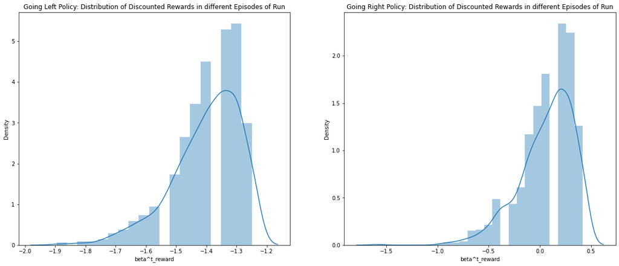

```python
# Plotting the Sum of discounted rewards in different episodes
sum_rewards_left = allEpisodes_same_state_left.groupby('episode')['beta^t_reward'].sum()

plt.figure(figsize=(20,8))
plt.subplot(1,2,1)
sns.distplot(sum_rewards_left)
plt.title('Going Left Policy: Distribution of Discounted Rewards in different Episodes of Run')


plt.subplot(1,2,2)
sns.distplot(sum_rewards)
plt.title('Going Right Policy: Distribution of Discounted Rewards in different Episodes of Run')
```

```python
sum_rewards_left.describe()
```

```
count    1000.000000
mean       -1.399273
std         0.113167
min        -1.895683
25%        -1.478151
50%        -1.392146
75%        -1.298903
max        -1.249378
Name: beta^t_reward, dtype: float64
```

#### Table 2.6: Summary statistics of the sum of discounted realized rewards across all episodes for each initial state

```python
allEpisodes_left = pd.DataFrame()
obs = range(1,20)
for o in obs:
    for e in range(0,1000):
        t=0
        tMAX = 50
        done = False
        observation = np.int(o)
        observations = [observation]
        rewards = []
        actions = []
        env = Segment(numActions=2,startObservation=observation,p=0.8,terminal=10,done=False)
        while t <tMAX and done==False:
            action = policy(observation=observation)
            observation_next,reward,done = env.step(action=action)
            observations.append(observation_next)
            rewards.append(reward)
            actions.append(action)
            observation = observation_next
            t+=1
        dta = pd.DataFrame(
                    [[o-10]*t,
                    [e]*t,
                    range(0,t),
                    observations[0:t],
                    observations[1:(t+1)],
                    actions[0:t],
                    rewards]).transpose()
        dta.columns = ['initial','episode','t','observation','observation_next','action','reward']
        dta['observation'] = dta['observation'] - 10
        dta['observation_next'] = dta['observation_next'] - 10
        dta['beta'] = 0.98
        dta['beta^t'] = dta['beta']**dta['t']
        dta['beta^t_reward'] = dta['beta^t']*dta['reward']
        allEpisodes_left = allEpisodes_left.append(dta,ignore_index=True)
```

```python
allEpisodes_left
```

[output not shown]

304262 rows × 10 columns

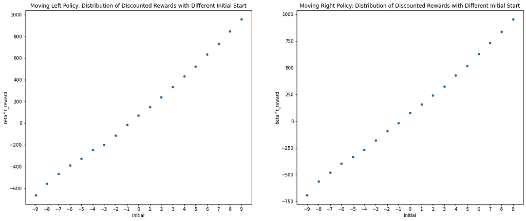

```python
# Plotting the Sum of discounted rewards in different episodes
sum_rewards_all_states_left = allEpisodes_left.groupby(['initial'])['beta^t_reward'].sum().reset_index()
sum_rewards_all_states_left

plt.figure(figsize=(20,8))

# Moving Left Policy
plt.subplot(1,2,1)
sns.scatterplot(sum_rewards_all_states_left['initial'], sum_rewards_all_states_left['beta^t_reward'])
plt.title('Moving Left Policy: Distribution of Discounted Rewards with Different Initial Start')
plt.xticks(range(-9, 10))

# Moving Right Policy
plt.subplot(1,2,2)
sns.scatterplot(sum_rewards_all_states['initial'], sum_rewards_all_states['beta^t_reward'])
plt.title('Moving Right Policy: Distribution of Discounted Rewards with Different Initial Start')
plt.xticks(range(-9, 10))
plt.show()
```

```python
transitions = allEpisodes_left['observation']

transitions_matrix_left = pd.DataFrame(transitions)
# create a new column with data shifted one space
transitions_matrix_left['shift'] = transitions_matrix_left.shift(-1)

# groupby and then unstack, fill the zeros
trans_mat_left = transitions_matrix_left.groupby(['observation', 'shift']).size().unstack().fillna(0)

# normalise by occurences and save values to get transition matrix
trans_mat_left = round(trans_mat_left/(trans_mat_left.sum(axis=1)),2)
trans_mat_left
```

[output not shown]

### 3) Under a policy that “tries to go left” with 50% probability and “tries to go right” with 50% probability:

1. rerun the code and recreate table 2.1, 2.4, and 2.6
2. recreate figures 2.2 and 2.3
3. construct the transition probability matrix

```python
t=0
tMAX = 100
done = False
observation = 10
observations = [observation]
rewards = []
actions = []

# this is a hard coded policy for going left
U = np.random.uniform(low=0, high=1)
def policy(observation):
    if np.random.uniform(low=0, high=1) <= 0.5:
        action = 0
    else:
        action = 1
    return action
```

#### Table 2.1 States, actions and rewards for each step in an episode

```python
env = Segment(numActions=2,startObservation=10,p=0.8,terminal=10,done=False)
while t <tMAX and done==False:
    action = policy(observation=observation)
    observation_next,reward,done = env.step(action=action)
    observations.append(observation_next)
    rewards.append(reward)
    actions.append(action)
    observation = observation_next
    t+=1
```

```python
dta_mix = pd.DataFrame(
             [range(0,t),
              observations[0:t],
              observations[1:(t+1)],
              actions[0:t],
              rewards]).transpose()

dta_mix.columns = ['t','observation','observation_next','action','reward']
dta_mix['observation'] = dta_mix['observation'] - 10
dta_mix['observation_next'] = dta_mix['observation_next'] - 10
dta_mix['beta'] = 0.98
dta_mix['beta^t'] = dta_mix['beta']**dta_mix['t']
dta_mix['beta^t_reward'] = dta_mix['beta^t']*dta_mix['reward']

print(dta_mix.shape)
dta_mix.tail()
```

```
(42, 8)
```

|  | t | observation | observation_next | action | reward | beta | beta^t | beta^t_reward |
| --- | --- | --- | --- | --- | --- | --- | --- | --- |
| 37 | 37.0 | -5.0 | -6.0 | 0.0 | -0.05 | 0.98 | 0.473549 | -0.023677 |
| 38 | 38.0 | -6.0 | -7.0 | 0.0 | -0.05 | 0.98 | 0.464078 | -0.023204 |
| 39 | 39.0 | -7.0 | -8.0 | 0.0 | -0.05 | 0.98 | 0.454796 | -0.022740 |
| 40 | 40.0 | -8.0 | -9.0 | 0.0 | -0.05 | 0.98 | 0.445700 | -0.022285 |
| 41 | 41.0 | -9.0 | -10.0 | 0.0 | -1.00 | 0.98 | 0.436786 | -0.436786 |

#### Table 2.4 Summary statistics of the sum of discounted realized rewards across all episodes

```python
# Running for all the episodes

allEpisodes_same_state_mix = pd.DataFrame()
for e in range(0,1000):
    t=0
    tMAX = 50
    done = False
    observation = 10
    observations = [observation]
    rewards = []
    actions = []
    env = Segment(numActions=2,startObservation=10,p=0.8,terminal=10,done=False)
    while t <tMAX and done==False:
        action = policy(observation=observation)
        observation_next,reward,done = env.step(action=action)
        observations.append(observation_next)
        rewards.append(reward)
        actions.append(action)
        observation = observation_next
        t+=1
    dta = pd.DataFrame(
                 [[e]*t,
                  range(0,t),
                  observations[0:t],
                  observations[1:(t+1)],
                  actions[0:t],
                  rewards]).transpose()
    dta.columns = ['episode','t','observation','observation_next','action','reward']
    dta['observation'] = dta['observation'] - 10
    dta['observation_next'] = dta['observation_next'] - 10
    dta['beta'] = 0.98
    dta['beta^t'] = dta['beta']**dta['t']
    dta['beta^t_reward'] = dta['beta^t']*dta['reward']
    allEpisodes_same_state_mix = allEpisodes_same_state_mix.append(dta,ignore_index=True)

allEpisodes_same_state_mix
```

|  | episode | t | observation | observation_next | action | reward | beta | beta^t | beta^t_reward |
| --- | --- | --- | --- | --- | --- | --- | --- | --- | --- |
| 0 | 0.0 | 0.0 | 0.0 | 1.0 | 1.0 | -0.05 | 0.98 | 1.000000 | -0.050000 |
| 1 | 0.0 | 1.0 | 1.0 | 0.0 | 0.0 | -0.05 | 0.98 | 0.980000 | -0.049000 |
| 2 | 0.0 | 2.0 | 0.0 | -1.0 | 0.0 | -0.05 | 0.98 | 0.960400 | -0.048020 |
| 3 | 0.0 | 3.0 | -1.0 | -2.0 | 0.0 | -0.05 | 0.98 | 0.941192 | -0.047060 |
| 4 | 0.0 | 4.0 | -2.0 | -3.0 | 0.0 | -0.05 | 0.98 | 0.922368 | -0.046118 |
| ... | ... | ... | ... | ... | ... | ... | ... | ... | ... |
| 44659 | 999.0 | 45.0 | -1.0 | -2.0 | 0.0 | -0.05 | 0.98 | 0.402878 | -0.020144 |
| 44660 | 999.0 | 46.0 | -2.0 | -3.0 | 0.0 | -0.05 | 0.98 | 0.394820 | -0.019741 |
| 44661 | 999.0 | 47.0 | -3.0 | -2.0 | 1.0 | -0.05 | 0.98 | 0.386924 | -0.019346 |
| 44662 | 999.0 | 48.0 | -2.0 | -1.0 | 0.0 | -0.05 | 0.98 | 0.379185 | -0.018959 |
| 44663 | 999.0 | 49.0 | -1.0 | 0.0 | 1.0 | -0.05 | 0.98 | 0.371602 | -0.018580 |

44664 rows × 9 columns

```
(-2.0, 0.5)
```

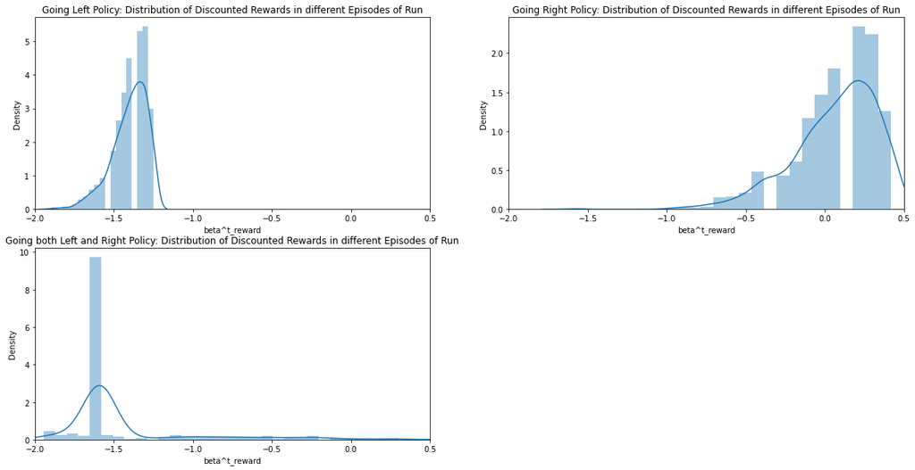

```python
# Plotting the Sum of discounted rewards in different episodes
sum_rewards_mix = allEpisodes_same_state_mix.groupby('episode')['beta^t_reward'].sum()

plt.figure(figsize=(20,10))
plt.subplot(2,2,1)
sns.distplot(sum_rewards_left)
plt.title('Going Left Policy: Distribution of Discounted Rewards in different Episodes of Run')
plt.xlim(-2, 0.5)


plt.subplot(2,2,2)
sns.distplot(sum_rewards)
plt.title('Going Right Policy: Distribution of Discounted Rewards in different Episodes of Run')
plt.xlim(-2, 0.5)

plt.subplot(2,2,3)
sns.distplot(sum_rewards_mix)
plt.title('Going both Left and Right Policy: Distribution of Discounted Rewards in different Episodes of Run')
plt.xlim(-2, 0.5)
```

```python
sum_rewards_mix.describe()
```

```
count    1000.000000
mean       -1.445857
std         0.411304
min        -1.942597
25%        -1.589576
50%        -1.589576
75%        -1.589576
max         0.302560
Name: beta^t_reward, dtype: float64
```

#### Table 2.6: Summary statistics of the sum of discounted realized rewards across all episodes for each initial state

```python
allEpisodes_mix = pd.DataFrame()
obs = range(1,20)
for o in obs:
    for e in range(0,1000):
        t=0
        tMAX = 50
        done = False
        observation = np.int(o)
        observations = [observation]
        rewards = []
        actions = []
        env = Segment(numActions=2,startObservation=observation,p=0.8,terminal=10,done=False)
        while t <tMAX and done==False:
            action = policy(observation=observation)
            observation_next,reward,done = env.step(action=action)
            observations.append(observation_next)
            rewards.append(reward)
            actions.append(action)
            observation = observation_next
            t+=1
        dta = pd.DataFrame(
                    [[o-10]*t,
                    [e]*t,
                    range(0,t),
                    observations[0:t],
                    observations[1:(t+1)],
                    actions[0:t],
                    rewards]).transpose()
        dta.columns = ['initial','episode','t','observation','observation_next','action','reward']
        dta['observation'] = dta['observation'] - 10
        dta['observation_next'] = dta['observation_next'] - 10
        dta['beta'] = 0.98
        dta['beta^t'] = dta['beta']**dta['t']
        dta['beta^t_reward'] = dta['beta^t']*dta['reward']
        allEpisodes_mix = allEpisodes_mix.append(dta,ignore_index=True)
```

```python
allEpisodes_mix
```

|  | initial | episode | t | observation | observation_next | action | reward | beta | beta^t | beta^t_reward |
| --- | --- | --- | --- | --- | --- | --- | --- | --- | --- | --- |
| 0 | -9.0 | 0.0 | 0.0 | -9.0 | -10.0 | 0.0 | -1.00 | 0.98 | 1.000000 | -1.000000 |
| 1 | -9.0 | 1.0 | 0.0 | -9.0 | -10.0 | 0.0 | -1.00 | 0.98 | 1.000000 | -1.000000 |
| 2 | -9.0 | 2.0 | 0.0 | -9.0 | -8.0 | 1.0 | -0.05 | 0.98 | 1.000000 | -0.050000 |
| 3 | -9.0 | 2.0 | 1.0 | -8.0 | -9.0 | 0.0 | -0.05 | 0.98 | 0.980000 | -0.049000 |
| 4 | -9.0 | 2.0 | 2.0 | -9.0 | -8.0 | 1.0 | -0.05 | 0.98 | 0.960400 | -0.048020 |
| ... | ... | ... | ... | ... | ... | ... | ... | ... | ... | ... |
| 619246 | 9.0 | 997.0 | 47.0 | -2.0 | -1.0 | 1.0 | -0.05 | 0.98 | 0.386924 | -0.019346 |
| 619247 | 9.0 | 997.0 | 48.0 | -1.0 | 0.0 | 1.0 | -0.05 | 0.98 | 0.379185 | -0.018959 |
| 619248 | 9.0 | 997.0 | 49.0 | 0.0 | -1.0 | 0.0 | -0.05 | 0.98 | 0.371602 | -0.018580 |
| 619249 | 9.0 | 998.0 | 0.0 | 9.0 | 10.0 | 1.0 | 1.00 | 0.98 | 1.000000 | 1.000000 |
| 619250 | 9.0 | 999.0 | 0.0 | 9.0 | 10.0 | 1.0 | 1.00 | 0.98 | 1.000000 | 1.000000 |

619251 rows × 10 columns

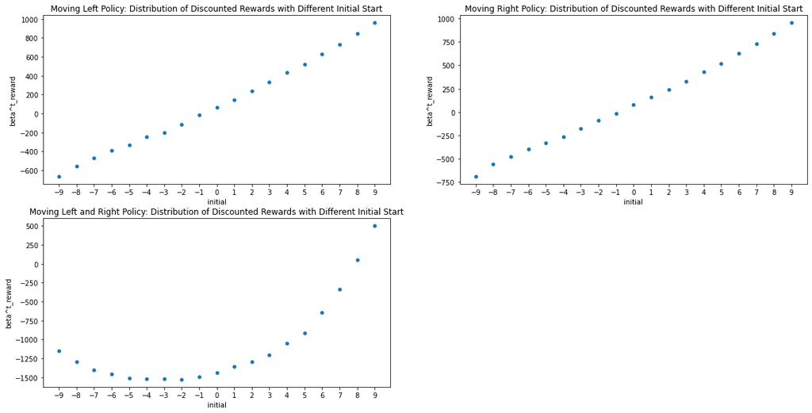

```python
# Plotting the Sum of discounted rewards in different episodes
sum_rewards_all_states_mix = allEpisodes_mix.groupby(['initial'])['beta^t_reward'].sum().reset_index()
sum_rewards_all_states_mix

plt.figure(figsize=(20,10))

# Moving Left Policy
plt.subplot(2,2,1)
sns.scatterplot(sum_rewards_all_states_left['initial'], sum_rewards_all_states_left['beta^t_reward'])
plt.title('Moving Left Policy: Distribution of Discounted Rewards with Different Initial Start')
plt.xticks(range(-9, 10))

# Moving Right Policy
plt.subplot(2,2,2)
sns.scatterplot(sum_rewards_all_states['initial'], sum_rewards_all_states['beta^t_reward'])
plt.title('Moving Right Policy: Distribution of Discounted Rewards with Different Initial Start')
plt.xticks(range(-9, 10))

# Moving Left and right Policy
plt.subplot(2,2,3)
sns.scatterplot(sum_rewards_all_states_mix['initial'], sum_rewards_all_states_mix['beta^t_reward'])
plt.title('Moving Left and Right Policy: Distribution of Discounted Rewards with Different Initial Start')
plt.xticks(range(-9, 10))

plt.show()
```

```python
transitions = allEpisodes_mix['observation']

transitions_matrix_mix = pd.DataFrame(transitions)
# create a new column with data shifted one space
transitions_matrix_mix['shift'] = transitions_matrix_mix.shift(-1)

# groupby and then unstack, fill the zeros
trans_mat_mix = transitions_matrix_mix.groupby(['observation', 'shift']).size().unstack().fillna(0)

# normalise by occurences and save values to get transition matrix
trans_mat_mix = round(trans_mat_mix/(trans_mat_mix.sum(axis=1)),2)
trans_mat_mix
```

| shift observation | -9.0 | -8.0 | -7.0 | -6.0 | -5.0 | -4.0 | -3.0 | -2.0 | -1.0 | 0.0 | 1.0 | 2.0 | 3.0 | 4.0 | 5.0 | 6.0 | 7.0 | 8.0 | 9.0 |
| --- | --- | --- | --- | --- | --- | --- | --- | --- | --- | --- | --- | --- | --- | --- | --- | --- | --- | --- | --- |
| -9.0 | 0.09 | 0.31 | 0.03 | 0.02 | 0.01 | 0.01 | 0.01 | 0.01 | 0.00 | 0.00 | 0.00 | 0.00 | 0.00 | 0.00 | 0.00 | 0.00 | 0.00 | 0.00 | 0.00 |
| -8.0 | 0.90 | 0.00 | 0.36 | 0.00 | 0.00 | 0.00 | 0.00 | 0.00 | 0.00 | 0.00 | 0.00 | 0.00 | 0.00 | 0.00 | 0.00 | 0.00 | 0.00 | 0.00 | 0.00 |
| -7.0 | 0.00 | 0.68 | 0.00 | 0.40 | 0.00 | 0.00 | 0.00 | 0.00 | 0.00 | 0.00 | 0.00 | 0.00 | 0.00 | 0.00 | 0.00 | 0.00 | 0.00 | 0.00 | 0.00 |
| -6.0 | 0.00 | 0.00 | 0.60 | 0.00 | 0.43 | 0.00 | 0.00 | 0.00 | 0.00 | 0.00 | 0.00 | 0.00 | 0.00 | 0.00 | 0.00 | 0.00 | 0.00 | 0.00 | 0.00 |
| -5.0 | 0.00 | 0.00 | 0.00 | 0.57 | 0.00 | 0.45 | 0.00 | 0.00 | 0.00 | 0.00 | 0.00 | 0.00 | 0.00 | 0.00 | 0.00 | 0.00 | 0.00 | 0.00 | 0.00 |
| -4.0 | 0.00 | 0.00 | 0.00 | 0.00 | 0.54 | 0.00 | 0.47 | 0.00 | 0.00 | 0.00 | 0.00 | 0.00 | 0.00 | 0.00 | 0.00 | 0.00 | 0.00 | 0.00 | 0.00 |
| -3.0 | 0.00 | 0.00 | 0.00 | 0.00 | 0.00 | 0.53 | 0.00 | 0.48 | 0.00 | 0.00 | 0.00 | 0.00 | 0.00 | 0.00 | 0.00 | 0.00 | 0.00 | 0.00 | 0.00 |
| -2.0 | 0.00 | 0.00 | 0.00 | 0.00 | 0.00 | 0.00 | 0.51 | 0.00 | 0.48 | 0.00 | 0.00 | 0.00 | 0.00 | 0.00 | 0.00 | 0.00 | 0.00 | 0.00 | 0.00 |
| -1.0 | 0.00 | 0.00 | 0.00 | 0.00 | 0.00 | 0.00 | 0.00 | 0.50 | 0.00 | 0.49 | 0.00 | 0.00 | 0.00 | 0.00 | 0.00 | 0.00 | 0.00 | 0.00 | 0.00 |
| 0.0 | 0.00 | 0.00 | 0.00 | 0.00 | 0.00 | 0.00 | 0.00 | 0.00 | 0.50 | 0.00 | 0.50 | 0.00 | 0.00 | 0.00 | 0.00 | 0.00 | 0.00 | 0.00 | 0.00 |
| 1.0 | 0.00 | 0.00 | 0.00 | 0.00 | 0.00 | 0.00 | 0.00 | 0.00 | 0.00 | 0.49 | 0.00 | 0.51 | 0.00 | 0.00 | 0.00 | 0.00 | 0.00 | 0.00 | 0.00 |
| 2.0 | 0.00 | 0.00 | 0.00 | 0.00 | 0.00 | 0.00 | 0.00 | 0.00 | 0.00 | 0.00 | 0.49 | 0.00 | 0.51 | 0.00 | 0.00 | 0.00 | 0.00 | 0.00 | 0.00 |
| 3.0 | 0.00 | 0.00 | 0.00 | 0.00 | 0.00 | 0.00 | 0.00 | 0.00 | 0.00 | 0.00 | 0.00 | 0.48 | 0.00 | 0.53 | 0.00 | 0.00 | 0.00 | 0.00 | 0.00 |
| 4.0 | 0.00 | 0.00 | 0.00 | 0.00 | 0.00 | 0.00 | 0.00 | 0.00 | 0.00 | 0.00 | 0.00 | 0.00 | 0.47 | 0.00 | 0.54 | 0.00 | 0.00 | 0.00 | 0.00 |
| 5.0 | 0.00 | 0.00 | 0.00 | 0.00 | 0.00 | 0.00 | 0.00 | 0.00 | 0.00 | 0.00 | 0.00 | 0.00 | 0.00 | 0.45 | 0.00 | 0.57 | 0.00 | 0.00 | 0.00 |
| 6.0 | 0.00 | 0.00 | 0.00 | 0.00 | 0.00 | 0.00 | 0.00 | 0.00 | 0.00 | 0.00 | 0.00 | 0.00 | 0.00 | 0.00 | 0.43 | 0.00 | 0.60 | 0.00 | 0.00 |
| 7.0 | 0.00 | 0.00 | 0.00 | 0.00 | 0.00 | 0.00 | 0.00 | 0.00 | 0.00 | 0.00 | 0.00 | 0.00 | 0.00 | 0.00 | 0.00 | 0.41 | 0.00 | 0.68 | 0.00 |
| 8.0 | 0.00 | 0.00 | 0.00 | 0.00 | 0.00 | 0.00 | 0.00 | 0.00 | 0.00 | 0.00 | 0.00 | 0.00 | 0.00 | 0.00 | 0.00 | 0.00 | 0.36 | 0.00 | 0.90 |
| 9.0 | 0.00 | 0.00 | 0.00 | 0.00 | 0.00 | 0.00 | 0.00 | 0.00 | 0.00 | 0.00 | 0.01 | 0.01 | 0.01 | 0.01 | 0.01 | 0.02 | 0.03 | 0.31 | 0.09 |